# act_report

## Report: act_report

- Create a **250-word-minimum written report** called "act_report.pdf" or "act_report.html" that communicates the insights and displays the visualization(s) produced from your wrangled data. This is to be framed as an external document, like a blog post or magazine article, for example.

## Overview

Wrangle project analysis consist of three dataset downloaded from tweets of variety of dog types. df_archive dataset consist of 2356 entries with 17 columns. This columns included retweet id's which are not needed for this analysis. df_image consists of 2075 entries with 12 columns, consisting of various dogs that were posted and its image url's. df_tweets had 2354 entries with 3 columns; id, retweets_count and favorite_count. tweet_id were duplicated in the three datasets and df_archive had a number of missing values. This analysis started on the 13th of june 2022 and was completed on the 19th of june, 2022. it took an approximate of 7 days to complete

## Variables

Descriptive analysis was done on the three tables to get the mean, max, min, percentage, number of missing values, number of duplicates, value counts of each variables and their unique values.

## Assesment

During the assesment stage eleven issues were identified; two tidiness issue and nine quality issues, which included erroneous datatype, null values, irrelevant columns, duplicate columns and four columns representing one variable.

## Cleaning

the problems identified in the assessment stage were cleaned using pandas functions. we ended up having two tables; archive_new and df_image_cleaned. These two tables were used for the exploratory data analysis.

## Exploratory data analysis

The value counts of the varierty of dog stages were gotten. The mean value of the retweeet_count and the maximum value of the retweet counts and favorite counts, together with the tweet-id associated with it.

## visualization

A pie chart was created on the dog and the number of posts it appeared. see image below;

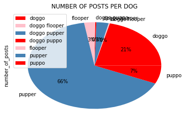

## Limitation

There were too many entries in the dataset, all of which were not original tweets. This made cleaning very tasking.

## Recommendation

This datasets require further cleaning for more analysis to be performed on it. i would suggest that more details about the dogs should be gathered, such as its size.

```python
from subprocess import call
call(['python', '-m', 'nbconvert', 'act_report.ipynb'])
```

```
0
```